# Homework

SA23204171

2023-12-08

# HW1

## Question 1

Go through “R for Beginners” if you are not familiar with R programming.

## Answer 1

Sure.

## Question 2

Use knitr to produce at least 3 examples. For each example, texts should mix with figures and/or tables. Better to have mathematical formulas.

## Answer 2

### example 1

- Latex

$$\hat{B}_{k,k'} = \begin{cases}
\frac{\sum_{i \in \mathcal{N}_{1,k}, \, j \in \mathcal{N}_{1,k'}
\cup \mathcal{N}_{2,k'}}A_{ij}}{n_{1,k}(n_{1,k'}+n_{2,k'})},
& k \neq k',\\
\frac{\sum_{i,j \in \mathcal{N}_{1,k}, \, i<j}A_{ij}+\sum_{i \in
\mathcal{N}_{1,k}, \, j \in
\mathcal{N}_{2,k}}A_{ij}}{(n_{1,k}-1)n_{1,k}/2+n_{1,k}n_{2,k}}, &
k=k'.
\end{cases}$$

### example 3

Here I try to change the color of the text and insert a link of a [webpage](https://www.bilibili.com/). I also insert 3 code chunks of R language, which respectively show and execute the code, show the code without executing it, and execute the code without showing it

#### show and execute the code

```r
x <- 1
y <- 2
print(x+y)
```

```
## [1] 3
```

#### show the code without executing it

```r
x <- 1
y <- 2
print(x+y)
```

#### execute the code without showing it

```
## [1] 3
```

## ——————————————————————————–

# HW2

## Question 1

Use the inverse transform method to implement the functions of ‘sample()’ when $replace = T$.

## Answer 1

```r
my.sample <- function(x, n, prob = NULL){
  ### 给定一有限总体，有放回地从中抽取样本
  #   x: 输入一个有限总体，为向量形式
  #   n: 从x中产生的随机数个数，为一正整数
  #   prob: 与x等长的向量，表示x中对应位次元素的入样概率，未指
  #定则默认等概率抽取

  if(is.null(prob)){
    # 未指定prob，默认等概率抽取
    p <- 1:length(x)/sum(1:length(x))
    cp <- cumsum(p)
    U <- runif(n)
    r <- x[findInterval(U, cp)+1]
  } else{
    # 用户指定了各元素入样概率
      if((length(prob) != length(x)) | (sum(prob) != 1)){
      # 用户指定的prob格式错误，则返回报错信息
      return("Wrong entry of the argument 'prob'!")
    } else{
      p <- cumsum(prob)
      U <- runif(n)
      r <- x[findInterval(U, p)+1]
    }
  }

  return(r) # 返回抽样结果，为一向量
}

# tests
x <- c(1, 2, 4, 10)
n <- 10
p1 <- 1:4/10
p2 <- c(0.3, 0.3, 0.4) # 错误指定prob
p3 <- c(0.1, 0.1, 0.3, 0.2, 0.3) # 错误指定prob
my.sample(x, n, p1)
```

```
##  [1] 10  2  2  4 10  4  2 10 10 10
```

```r
my.sample(x, n, p2)
```

```
## [1] "Wrong entry of the argument 'prob'!"
```

```r
my.sample(x, n, p3)
```

```
## [1] "Wrong entry of the argument 'prob'!"
```

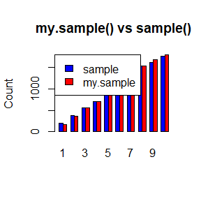

```r
# comparison with 'sample()'
x1 <- 1:10
pr <- 1:10/sum(1:10)
N <- 10000
res1 <- sample(x1, N, prob = pr, replace = T)
res2 <- my.sample(x1, N, prob = pr)
counts <- table(c(rep(0, N), rep(1, N)), c(res1, res2))
barplot(counts,
        main="my.sample() vs sample()",
        ylab='Count',
        col=c("blue","red"),
        beside=TRUE)
legend('topleft',
       fill = c('blue', 'red'),
       col = c('blue', 'red'),
       legend = c('sample', 'my.sample'))
```

## Question 2

3.2 The standard Laplace distribution has density $f(x) = \frac{1}{2}e^{-\vert x \vert},\, x \in \mathbb{R}$. Use the inverse transform method to generate a random sample of size 1000 from this distribution. Use one of the methods shown in this chapter to compare the generated sample to the target distribution.

## Answer 2

由标准Laplace分布的密度函数容易求得其累积分布函数为
$$F(x) = \begin{cases} \frac 12 e^x, & x \le 0
\\ 1-\frac12 e^{-x}, & x > 0 \end{cases}$$
注意到$F(x)$在$\mathbb{R}$上严格单调递增，因此容易求得其反函数为
$$F^{-1}(x) = \begin{cases} \text{log}(2x), & x
\in (0, \frac12] \\ -\text{log}(2-2x), & x \in (\frac12, 1)
\end{cases}$$
因此由逆变换法根据标准Laplace分布生成1000个随机数的算法如下：

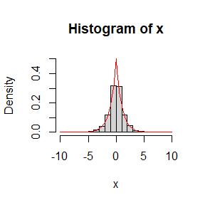

```r
u <- runif(1000)
x <- ifelse(u <= 0.5, log(2*u), -log(2-2*u))
# 对生成的随机数做直方图
hist(x,
     freq = F,
     xlim = c(-10, 10),
     ylim = c(0, 0.5))
# 叠加标准Laplace分布的密度曲线
curve(0.5*exp(-abs(x)),
      col = 'red',
      lwd = 1.5,
      from = -10, to = 10,
      add = T)
```

## Question 3

Write a function to generate a random sample of size n from the $Beta(a, b)$ distribution by the acceptance-rejection method. Generate a random sample of size 1000 from the $Beta(3,2)$ distribution. Graph the histogram of the sample with the theoretical $Beta(3,2)$ density superimposed.

## Answer 3

$Beta(a, b)$分布的概率密度函数为
$$f(x)=\frac{\Gamma(a+b)}{\Gamma(a)\Gamma(b)}x^{a-1}(1-x)^{b-1},
\quad 0<x<1$$
求导得
$$f'(x) =
\frac{\Gamma(a+b)}{\Gamma(a)\Gamma(b)}\cdot[(a-1)x^{a-2}(1-x)^{b-1} -
(b-1)x^{a-1}(1-x)^{b-2}]$$
令$f'(x)=0$求得$f(x)$的极大值点为
$$x_0=\frac{a-1}{a+b-2}$$
带入有$f(x)$的极大值为
$$f(x_0)=\frac{\Gamma(a+b)}{\Gamma(a)\Gamma(b)}\cdot(\frac{a-1}{a+b-2})^{a-1}(\frac{b-1}{a+b-2})^{b-1}$$
因此在接受-拒绝算法中，包络分布可取$Uniform(0, 1)$，即$g(x) = 1, \, c = f(x_0)$，使得
$$\rho(x)=\frac{f(x)}{cg(x)}=\frac{(a+b-2)^{a+b-2}x^{a-1}(1-x)^{b-1}}{(a-1)^{a-1}(b-1)^{b-1}}
\le 1.$$

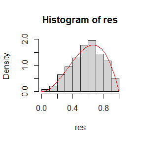

```r
# generation function
my.rbeta <- function(a, b, size){

  n <- size
  result <- numeric(n) # 生成的随机序列储存在向量result中
  flag <- 1 # 计数变量，一旦大于n则退出whlie循环

  # rho()函数
  rho <- function(x){
    m1 <- (a+b-2)^(a+b-2) * x^(a-1) * (1-x)^(b-1)
    m2 <- (a-1)^(a-1) * (b-1)^(b-1)
    return(m1/m2)
  }

  while(flag <= n){
    u <- runif(1) # 生成一个U(0, 1)上的随机数
    y <- runif(1) # 生成来自包络分布的一个随机数
    if(u <= rho(y)){
      result[flag] <- y
      flag <- flag + 1
    }
  }

  return(result)
}

# tests
res <- my.rbeta(3, 2, 1000)
# 对生成的随机数做直方图
hist(res,
     probability = T ,
     xlim = c(0, 1))
# 叠加Beta(3, 2)分布的密度曲线
curve(12* x^2 * (1-x),
      col = 'red',
      lwd = 1.5,
      from = 0, to = 1,
      add = T)
```

## Question 4

The rescaled Epanechnikov kernel is a symmetric density function
$$f_e(x) = \frac34(1-x^2), \quad \vert x
\vert \leq 1.$$
Devroye and Gyorfi give the following algorithm for simulation from this distribution. Generate i.i.d. $U_1, U_2, U_3$ ~ $U(-1, 1)$. If $\vert U_3\vert \geq \vert U_2 \vert$ and $\vert U_3\vert \ge \vert U_1 \vert$, deliver $U_2$; otherwise deliver $U_3$. Write a function to generate random variates from $f_e$, and construct the histogram density estimate of a large simulated random sample.

## Answer 4

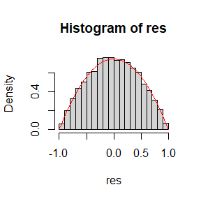

```r
# generation function
my.repanechnikov <- function(size){

  n <- size
  result <- numeric(n) # 生成的随机序列储存在向量result中

  for(i in 1:n){
    r <- runif(3, -1, 1)
    if((abs(r[3]) >= abs(r[2])) & (abs(r[3]) >= abs(r[1]))){
      result[i] <- r[2]
    } else{
      result[i] <- r[3]
    }
  }

  return(result)
}

# tests
n <- 10000
res <- my.repanechnikov(n)
# 对生成的随机数做直方图
hist(res,
     probability = T ,
     xlim = c(-1, 1))
# 叠加Epanechnikov核密度曲线
curve(3*(1-x^2)/4,
      col = 'red',
      lwd = 1.5,
      from = -1, to = 1,
      add = T)
```

## Question 5

Prove that the algorithm given in Ex 3.9 generates variates from the density $f_e$ in Ex 3.9.

## Answer 5

$proof.$

令$V = \text{max}\{\vert U_1\vert, \, \vert U_2\vert, \, \vert U_3\vert\}$, 并记事件$A=\{V=\vert U_3 \vert\}$. 由对称性有$\mathbb{P}(A)=\frac13$, $\mathbb{P}(A^c)=\frac23$. 易知分布$Uniform(-1, \, 1)$的密度函数为$f_U(x)=\frac12\text{I}(-1 < x < 1)$, 累积分布函数为$F_U(x)=\frac{x+1}2, \; x \in (-1,\, 1)$.

${\forall}x \in (-1,\,1)$,
$$\begin{aligned}
\mathbb{P}(X \le x)
&= \mathbb{P}(X \le x \vert A)\mathbb{P}(A)+\mathbb{P}(X \le x \vert
A^c)\mathbb{P}(A^c) \\
&= \mathbb{P}(U_2 \le x \vert A) \cdot \frac13+\mathbb{P}(U_3 \le x
\vert A^c) \cdot \frac23 \\
&= \frac{\mathbb{P}(U_2 \le x,\, A)}{\mathbb{P}(A)} \cdot
\frac13+\frac{\mathbb{P}(U_3 \le x,\, A^c)}{\mathbb{P}(A^c)} \cdot
\frac23 \\
&= \mathbb{P}(U_2 \le x,\, V=\vert U_3 \vert)+\mathbb{P}(U_3 \le
x,\, V \neq \vert U_3 \vert) \quad (\star)
\end{aligned}$$
注意到
$$\{U_3 \le x,\,
V \neq \vert U_3 \vert\}=\{U_3 \le x,\, V=\vert U_1 \vert\} \cup \{U_3
\le x,\, V=\vert U_2 \vert\}$$
而
$$\{U_3 \le x,\, V=\vert U_1 \vert\} \cap \{U_3 \le
x,\, V=\vert U_2 \vert\} \subset \{\vert U_1 \vert = \vert U_2
\vert\}$$
上式右端在$U_1,\, U_2$ i.i.d. ~ $Uniform(-1,\, 1)$时为零概率事件, 故
$$\begin{aligned}
\mathbb{P}(U_3 \le x,\, V \neq \vert U_3 \vert)
&= \mathbb{P}(U_3 \le x,\, V=\vert U_1 \vert)+\mathbb{P}(U_3 \le
x,\, V=\vert U_2 \vert) \\
&\overset{i.i.d}{=} 2\mathbb{P}(U_2 \le x,\, V=\vert U_3 \vert)
\end{aligned}$$
从而
$$\begin{aligned}
(\star)
&= \frac32\mathbb{P}(U_3 \le x,\, V \neq \vert U_3 \vert) \\
&= \frac32[\mathbb{P}(U_3 \le x)-\mathbb{P}(U_3 \le x,\, V=\vert U_3
\vert)] \\
&= \frac32[\frac{x+1}2 - \mathbb{P}(U_3 \le x,\, \vert U_1 \vert \le
\vert U_3 \vert,\, \vert U_2 \vert \le \vert U_3 \vert)] \quad (\star
\star)
\end{aligned}$$
$$\begin{aligned}
\mathbb{P}(U_3 \le x,\, \vert U_1 \vert \le \vert U_3 \vert ,\, \vert
U_2 \vert \le \vert U_3 \vert \, \Big| \, U_3 = y)
&= \mathbb{P}(y \le x,\, \vert U_1 \vert \le \vert y \vert ,\, \vert
U_2 \vert \le \vert y \vert \, \Big| \, U_3 = y) \\
&= \text{I}(y \le x) \cdot \mathbb{P}(\vert U_1 \vert \le \vert y
\vert) \cdot \mathbb{P}(\vert U_2 \vert \le y) \\
&= \vert y \vert^2 \cdot \text{I}(y \le x)
\end{aligned}$$
于是
$$\begin{aligned}
\mathbb{P}(U_3 \le x,\, \vert U_1 \vert \le \vert U_3 \vert ,\, \vert
U_2 \vert \le \vert U_3 \vert)
&= \mathbb{E}[\mathbb{P}(U_3 \le x,\, \vert U_1 \vert \le \vert U_3
\vert ,\, \vert U_2 \vert \le \vert U_3 \vert \, \Big| \, U_3)] \\
&= \mathbb{E}[\vert U_3 \vert^2 \text{I}(U_3 \le x)] \\
&= \int_{-\infty}^x \vert y \vert^2 f_U(y) dy \\
&= \int_{-\infty}^x y^2 \cdot \frac12 \text{I}(-1 \le y \le 1) dy \\
&= \int_{-1}^x \frac12 y^2 dy \\
&= \frac{x^3+1}6
\end{aligned}$$
从而
$$\begin{aligned}
(\star \star)
&= \frac32(\frac{x+1}2-\frac{x^3+1}6) \\
&= \frac34(x+1-\frac{x^3+1}3)
\end{aligned}$$
即: ${\forall}x \in (-1,\, 1)$, $\mathbb{P}(X \le x)=\frac34(x+1-\frac{x^3+1}3)$, 故$\frac{d\mathbb{P}(X \le x)}{dx}=\frac34(1-x^2)=f_e(x)$.

证毕.

## ——————————————————————————–

# HW3

## Question 1

What value should $\rho=\frac l d$ take to minimize the asymptotic variace of $\hat{\pi}=\frac{2\rho}{\hat{p}}$, where $\hat{p}=\frac m n$?

## Answer 1

Buffon投针试验的成功概率为$p=\frac{2\rho}{\pi}$, 其中$\rho=\frac l d$. 设$n$次投针试验的成功次数为$m$, 则$m$~$B(n,\, p)$, 用频率来估计概率可得$\hat{\pi}=\frac{2\rho}{\hat{p}}$, 其中$\hat{p}=\frac m n$. 记$\sigma^2=p(1-p)$, 由CLT, $\sqrt{n}(\hat{p}-p) \stackrel{d}{\rightarrow} N(0, \sigma^2)$. 现令$g(x)=\frac{2\rho}{x}$, $g'(x)=-\frac{2\rho}{x^2}$, $g'(p)=-\frac{2\rho}{p^2}=-\frac{\pi^2}{2\rho} \neq 0$, 故由Delta定理, $\sqrt{n}(g(\hat{p})-g(p)) \stackrel{d}{\rightarrow} N(0, \sigma^2(g'(p))^2)$, 即$\hat{\pi}$的渐近方差为$\frac{\sigma^2(g'(p))^2}{n}=\frac{\sigma^2(-\frac{\pi^2}{2\rho})^2}{n}=\frac{p(1-p)\frac{\pi^4}{4\rho^2}}{n}=\frac{\pi^2}{2n} \cdot \frac{\pi-2\rho}{\rho}=\frac{\pi^2}{2n} \cdot (\frac \pi \rho-2)$. 由于$l \le d$, 因此使得$\hat{\pi}$的渐近方差最小化的$\rho$为$\rho_{min}=1$, 最小渐近方差为$\frac{\pi^2(\pi-2)}{2n}$.

## Question 2

Take 3 different values of $\rho\; (0 \le \rho \le 1,\, \text{including } \rho_{min})$ and use Monte-Carlo simulation to verify your answer.($n=10^6,\, \text{number of repeated simulations } K=100$)

## Answer 2

```r
# rho_min = 1, 另外两个rho为0.5、0.8
rho <- c(1, 0.5, 0.8)
# 固定两平行线之间的距离d, 针长l = rho * d的改变通过rho的改变来实现
d <- 1
# 重复模拟次数
K <- 100
# 每次模拟的投针次数
n <- 1e6
# 模拟结果存储在该列表中
result <- list("rho_is_1" = numeric(K),
               "rho_is_0.5" = numeric(K),
               "rho_is_0.8" = numeric(K))

for(i in 1:3){
  for(k in 1:K){
    l <- d*rho[i]
    X <- runif(n, 0, d/2)
    Y <- runif(n, 0, pi/2)
    pi_hat <- 2*rho[i]/mean((l/2*sin(Y))>X)
    result[[i]][k] <- pi_hat
  }
}

# rho = 1的方差
var(result$rho_is_1)
```

```
## [1] 5.330487e-06
```

```r
# rho = 0.5的方差
var(result$rho_is_0.5)
```

```
## [1] 1.799878e-05
```

```r
# rho = 0.8的方差
var(result$rho_is_0.8)
```

```
## [1] 1.02441e-05
```

## Question 3

5.6 In Example 5.7 the control variate approach was illustrated for Monte Carlo integration of
$$\theta=\int_0^1
e^xdx.$$
Now consider the antithetic variate approach. Compute $Cov(e^U,\, e^{1-U})$ and $Var(e^U+e^{1-U})$, where $U$ ~ Uniform(0, 1). What is the percent reduction in variance of $\hat{\theta}$ that can be achieved using antithetic variates (compared with simple MC)?

## Answer 3

首先, $Cov(e^U,\, e^{1-U})=\mathbb{E}(e^U \cdot e^{1-U})-\mathbb{E}(e^U) \cdot \mathbb{E}(e^{1-U})=e-(e-1)^2=-e^2+3e-1.$

其次, $Var(e^U+e^{1-U})=\mathbb{E}(e^U+e^{1-U})^2-[\mathbb{E}(e^U+e^{1-U})]^2=(\text{I})-(\text{II})$, 其中$(\text{I})=\mathbb{E}(e^{2U}+e^{2-2U}+2e)=\frac{e^2-1}{2}+\frac{e^2-1}{2}+2e=e^2+2e-1$, $(\text{II})=(e-1+e-1)^2=4(e-1)^2$, 故$Var(e^U+e^{1-U})=-3e^2+10e-5.$

对于$\theta=\int_0^1e^xdx$, 简单MC估计量为$\hat{\theta_1}=\frac 1 n \sum_{i=1}^n e^{U_i}$, 对偶变量估计量为$\hat{\theta_2}=\frac 1 n \sum_{i=1}^{\frac n 2}(e^{U_i}+e^{1-U_i}).$

$Var(\hat{\theta_1})=Var(\frac 1 n \sum_{i=1}^n e^{U_i})=\frac 1 n Var(e^{U_1})=\frac 1 n [\mathbb{E}e^{2U}-(\mathbb{E}e^U)^2]=\frac 1 n[\frac{e^2-1}{2}-(e-1)^2]=\frac{-e^2+4e-3}{2n}$

$Var({\hat{\theta_2}})=Var(\frac 1 n \sum_{i=1}^{\frac n 2}(e^{U_i}+e^{1-U_i}))=\frac{1}{n^2} \cdot \frac n 2 Var(e^{U_1}+e^{1-U_1})=\frac{-3e^2+10e-5}{2n}$

因此对偶变量估计量的方差比简单MC估计量的方差减少百分比为: $\frac{Var({\hat{\theta_1}})-Var({\hat{\theta_2}})}{Var({\hat{\theta_1}})} \times 100\%=\frac{\frac{-e^2+4e-3}{2n}-\frac{-3e^2+10e-5}{2n}}{\frac{-e^2+4e-3}{2n}} \times 100\% \approx 96.77 \%$

## Question 4

5.7 Refer to Exercise 5.6. Use a Monte Carlo simulation to estimate $\theta$ by the antithetic variate approach and by the simple Monte Carlo method. Compute an empirical estimate of the percent reduction in variance using the antithetic variate. Compare the result with the theoretical value from Exercise 5.6.

## Answer 4

```r
# 产生N个均匀随机变量用以计算MC估计量
N <- 2000
# 重复模拟K次
K <- 500

# simple MC method
theta1_hat <- numeric(K)
for(i in 1:K){
  u <- runif(N)
  theta1_hat[i] <- mean(exp(u))
}
va1 <- var(theta1_hat); va1
```

```
## [1] 0.0001269217
```

```r
# antithetic variate approach
theta2_hat <- numeric(K)
for(i in 1:K){
  u <- runif(N/2)
  theta2_hat[i] <- sum(exp(u) + exp(1-u))/N
}
va2 <- var(theta2_hat); va2
```

```
## [1] 3.935876e-06
```

```r
# 方差减少的百分比
cat(round((va1-va2)*100/va1, 2), '%', sep = '')
```

```
## 96.9%
```

## ——————————————————————————–

# HW4

## Question 1

Prove that if $g$ is a continuous function over $(a,\,b)$, then $\frac{\text{Var}(\hat{\theta}^S)}{\text{Var}(\hat{\theta}^M)} \rightarrow 0$ as $b_i-a_i \rightarrow 0$ for all $i=1,\,2,\,\dots,\,k$.

## Answer 1

$Var(\hat{\theta}^S)=\frac{1}{Mk}\sum_{i=1}^k Var\big[g(U)\,\vert\,I=i\big]$.

记$\bar{\theta}=\mathbb{E}\theta_I=\mathbb{E}\big[\mathbb{E}(\theta_I \,\vert\,I)\big]=\sum_{i=1}^k\mathbb{P}(I=i)\cdot \mathbb{E}\big(\theta_I\,\vert\,I=i\big)=\frac1k\sum_{i=1}^k\theta_i$.

$\frac1MVar(\theta_I)=\frac1M \mathbb{E}\big[ \theta_I -\mathbb{E}\theta_I \big]^2=\frac1M\mathbb{E}(\theta_I-\bar{\theta})^2=\frac1M\mathbb{E}\{ \mathbb{E}\big[(\theta_I-\bar{\theta})^2\,\vert\, I\big]\}=\frac1M\sum_{i=1}^k\mathbb{P}(I=i)\cdot\mathbb{E}\big[(\theta_I-\bar{\theta})^2\,\vert\,I=i\big]=\frac{1}{Mk}\sum_{i=1}^k(\theta_i-\bar{\theta})^2$.

问题等价于证明$\frac{Var(\hat{\theta}^S)}{\frac1MVar(\theta_I)} \rightarrow 0$.
$$\begin{aligned}
\frac{Var(\hat{\theta}^S)}{\frac1MVar(\theta_I)}
&= \frac{\frac{1}{Mk}\sum_{i=1}^kVar\big[ g(U) \,\Big\vert\,I=i
\big]}{\frac{1}{Mk}\sum_{i=1}^k(\theta_i-\bar{\theta})^2} \\
&= \frac{\sum_{i=1}^kVar\big[ g(U) \,\Big\vert\,I=i
\big]}{\sum_{i=1}^k(\theta_i-\bar{\theta})^2} \\
&=
\frac{\sum_{i=1}^kVar[g(U_{1i})]}{\sum_{i=1}^k(\theta_i-\bar{\theta})^2}
\\
&= \frac{\sum_{i=1}^k\mathbb{E}\big[
g(U_{1i})-\mathbb{E}g(U_{1i})\big]^2}{\sum_{i=1}^k(\theta_i-\bar{\theta})^2}
\quad (*)
\end{aligned}$$
注意到$\theta_i=\mathbb{E}\big[g(U) \,\Big\vert\,I=i\big]=\mathbb{E}g(U_{1i})$,而$U_{1i}$ ~ $Uniform(a_i,\,b_i)$ 因此:
$$\begin{aligned}
(*)
&= \frac{\sum_{i=1}^k\mathbb{E}\big[
g(U_{1i})-\theta_i\big]^2}{\sum_{i=1}^k(\theta_i-\bar{\theta})^2} \\
&= \frac{\sum_{i=1}^k\int_{a_i}^{b_i}\big[
g(t)-\theta_i\big]^2\frac{dt}{b_i-a_i}}{\sum_{i=1}^k(\theta_i-\bar{\theta})^2}
\\
&= \frac{\sum_{i=1}^k\int_{a_i}^{b_i}\big[
g(t)-\bar{\theta}+\bar{\theta}-\theta_i\big]^2\frac{dt}{b_i-a_i}}{\sum_{i=1}^k(\theta_i-\bar{\theta})^2}
\\
&=
\frac{\sum_{i=1}^k\int_{a_i}^{b_i}\big(g(t)-\bar{\theta}\big)^2\frac{dt}{b_i-a_i}+\sum_{i=1}^k\int_{a_i}^{b_i}\big(\theta_i-\bar{\theta}\big)^2\frac{dt}{b_i-a_i}+2\sum_{i=1}^k\int_{a_i}^{b_i}\big(g(t)-\bar{\theta}\big)(\bar{\theta}-\theta_i)\frac{dt}{b_i-a_i}}{\sum_{i=1}^k(\theta_i-\bar{\theta})^2}
\\
&=
\frac{\sum_{i=1}^k\int_{a_i}^{b_i}\big(g(t)-\bar{\theta}\big)^2\frac{dt}{b_i-a_i}+\sum_{i=1}^k(\theta_i-\bar{\theta})^2-2\sum_{i=1}^k(\theta_i-\bar{\theta})\int_{a_i}^{b_i}\big(g(t)-\bar{\theta}\big)\frac{dt}{b_i-a_i}}{\sum_{i=1}^k(\theta_i-\bar{\theta})^2}
\\
&=
\frac{\sum_{i=1}^k\int_{a_i}^{b_i}\big(g(t)-\bar{\theta}\big)^2\frac{dt}{b_i-a_i}+\sum_{i=1}^k(\theta_i-\bar{\theta})^2-2\sum_{i=1}^k(\theta_i-\bar{\theta})^2}{\sum_{i=1}^k(\theta_i-\bar{\theta})^2}
\\
&=
\frac{\sum_{i=1}^k\int_{a_i}^{b_i}\big(g(t)-\bar{\theta}\big)^2\frac{dt}{b_i-a_i}}{\sum_{i=1}^k(\theta_i-\bar{\theta})^2}-1\\
&=
\frac{\sum_{i=1}^k\mathbb{E}[g(U_{1i})-\bar{\theta}]^2}{\sum_{i=1}^k(\theta_i-\bar{\theta})^2}-1
\quad (**)
\end{aligned}$$
显然当$b_i-a_i \rightarrow 0\;(\Rightarrow k \rightarrow \infty)$时, $(**) \rightarrow \frac{\sum_{i=1}^k(\theta_i-\bar{\theta})^2}{\sum_{i=1}^k(\theta_i-\bar{\theta})^2}-1=0$

## Question 2

Find two importance functions $f_1$ and $f_2$ that are supported on $(1,\, \infty)$ and are ‘close’ to $g(x)=\frac{x^2}{\sqrt{2\pi}}e^{-x^2/2},\quad x>1$. Which of your two importance functions should produce the smaller variance in estimating $\int_1^\infty \frac{x^2}{\sqrt{2\pi}}e^{-x^2/2}dx$ by importance sampling? Explain.

## Answer 2

$f_1(x)=e^{1-x},\;x>1$.

$f_2(x)=xe^{\frac{1-x^2}{2}},\;x>1$.

```r
N=100 #重复模拟100次
m=1000 #每次产生的随机数个数
res1 <- numeric(N) #用f_1估计的结果向量
res2 <- numeric(N) #用f_2估计的结果向量

# 3个函数
f1 <- function(x) exp(1-x) * (x>1)
f2 <- function(x) x * exp((1-x^2)/2) * (x>1)
g <- function(x) x^2 * exp(-x^2/2) * (x>1) / sqrt(2*pi)

# 用f_1进行估计
for (i in 1:N){
  # 用逆变换法产生m个来自f1分布的随机数
  f1_rev <- function(x) 1 - log(1-x)
  u <- runif(m)
  x <- f1_rev(u)
  res1[i] <- sum(g(x)/f1(x))/m
}

# 用f_2进行估计
for (i in 1:N){
  # 用逆变换法产生m个来自f2分布的随机数
  f2_rev <- function(x) sqrt(1 - 2*log(1-x))
  u <- runif(m)
  x <- f2_rev(u)
  res2[i] <- sum(g(x)/f2(x))/m
}

# 求方差, 可以看出用f2求出的估计方差更小
var(res1)
```

```
## [1] 2.841719e-05
```

```r
var(res2)
```

```
## [1] 1.653238e-05
```

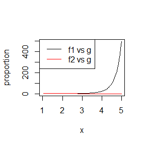

```r
# 作图分别查看f1与g、f2与g的正比关系:
f1_g <- function(x) f1(x)/g(x)
f2_g <- function(x) f2(x)/g(x)
curve(f1_g(x),
      from = 1, to = 5,
      xlab = 'x', ylab = 'proportion')
curve(f2_g(x),
      from = 1, to = 5,
      col = 'red',
      add = T)
legend('topleft',
       lty = c(1, 1),
       col = c('black', 'red'),
       legend = c('f1 vs g', 'f2 vs g'))
```

```r
# 显然f2与g的正比关系更强
```

## Question 3

Obtain a Monte Carlo estimate of $\int_1^\infty \frac{x^2}{\sqrt{2\pi}}e^{-x^2/2}dx$ by importance sampling.

## Answer 3

在Question 2的解答中已经用Monte Carlo方法给出了在两种重要性函数下目标参数的估计，并分别重复模拟了100次，这里直接给出Answer 2中的结果向量的部分值:

```r
head(res1)
```

```
## [1] 0.3906320 0.3962580 0.3962332 0.3924979 0.3992230 0.4000920
```

```r
head(res2)
```

```
## [1] 0.3975481 0.4024028 0.4050297 0.3991408 0.4037631 0.4046884
```

## Question 4

Obtain the stratified importance sampling estimate in Example 5.13 and compare it with the result of Example 5.10.